# Adv. Data Mining Project - Sonar: Mines vs. Rocks

Ryan Durfey

Wednesday, June 10, 2015

# **SONAR: MINES vs. ROCKS**

## Introduction

It has been estimated that during World War II, between 600,000 and 1,000,000 sea mines were laid in various oceans and seas (http://en.wikipedia.org/wiki/Naval_mine). Many of these have gone missing or unaccounted for and still pose a threat to ships and submarines. Thus, searching and identifying potential mines has become an important task. While oftentimes detailed historical records, charting where mines were laid are useful, they are not always available. To search for unrecorded mines, sonar has been employed. However, a challenge with this approach is correctly identifying mines from benign rocks.

Using frequency-modulated “chirps,” sonar signals are bounced off of an object at various angles. The energy that is observed can then be analyzed and incorporated into a dataset. For this dataset in particular, each chirp pattern is a set of 60 numbers ranging from 0.0 to 1.0. Each of the 60 variables represents a particular frequency band and each instance is the energy observed. There are 208 examples in the dataset.

Our task is to accurately predict the type of object being scanned as either a mine (M) or a rock (R). We will create multiple prediction models and observe how effective each is. Additionally, due to the high number of variables/dimensions in relation to the small number of examples, employing a dimension-reduction technique (PCA) may be prove useful.

## Data Preparation

Our dataset is taken from the KEEL Dataset Repository, and can be accessed [HERE](http://sci2s.ugr.es/keel/dataset.php?cod=85).

```r
set.seed(4)

## load in the data
sonar<-read.table("./sonar.dat",skip=65,sep=",")
names(sonar)<-c(paste(rep("Band",60),1:60,sep=""),"Type")

## first look at the data
head(sonar)
```

```
##   Band1 Band2 Band3 Band4 Band5 Band6 Band7 Band8 Band9 Band10 Band11
## 1 0.020 0.037 0.043 0.021 0.095 0.099 0.154 0.160 0.311  0.211  0.161
## 2 0.045 0.052 0.084 0.069 0.118 0.258 0.216 0.348 0.334  0.287  0.492
## 3 0.026 0.058 0.110 0.108 0.097 0.228 0.243 0.377 0.560  0.619  0.633
## 4 0.010 0.017 0.062 0.020 0.020 0.037 0.110 0.128 0.060  0.126  0.088
## 5 0.076 0.067 0.048 0.039 0.059 0.065 0.121 0.247 0.356  0.446  0.415
## 6 0.029 0.045 0.028 0.017 0.038 0.099 0.120 0.183 0.210  0.304  0.299
##   Band12 Band13 Band14 Band15 Band16 Band17 Band18 Band19 Band20 Band21
## 1  0.158  0.224  0.064  0.066  0.227  0.310  0.300  0.508  0.480  0.578
## 2  0.655  0.692  0.780  0.746  0.944  1.000  0.887  0.802  0.782  0.521
## 3  0.706  0.554  0.532  0.648  0.693  0.676  0.755  0.893  0.862  0.797
## 4  0.199  0.018  0.226  0.173  0.213  0.069  0.228  0.406  0.397  0.274
## 5  0.395  0.426  0.414  0.453  0.533  0.731  0.619  0.203  0.464  0.415
## 6  0.425  0.634  0.820  1.000  0.999  0.951  0.902  0.723  0.512  0.207
##   Band22 Band23 Band24 Band25 Band26 Band27 Band28 Band29 Band30 Band31
```

[output cut: 27 more lines]

## **UNSUPERVISED LEARNING TECHNIQUES**

## Dimensionality Reduction: PCA

Our inital dataset has a large number of predictors, 60, and a relatively small number of examples, 208. Due to this, it may be more difficult to create prediction models later on. Reducing the dimensionality of the data will allow us to have fewer predictors without sacrificing too much of the variation in the data. To do this, we’ll perform a Principal Component Analysis.

```r
set.seed(4)

## scaled data needed for PCA (with the DV removed)
scaled_data<-scale(sonar[,-61])

## initial PCA
PCA<-prcomp(scaled_data,scaled=TRUE) # sometimes 'scaled' parameter doesn't work, so done manually above
summary(PCA)
```

```
## Importance of components:
##                           PC1    PC2     PC3     PC4     PC5     PC6
## Standard deviation     3.4941 3.3673 2.26413 1.84710 1.73321 1.56241
## Proportion of Variance 0.2035 0.1890 0.08544 0.05686 0.05007 0.04069
## Cumulative Proportion  0.2035 0.3925 0.47790 0.53476 0.58483 0.62552
##                            PC7     PC8     PC9   PC10    PC11    PC12
## Standard deviation     1.40171 1.35306 1.24052 1.2222 1.11659 1.06857
## Proportion of Variance 0.03275 0.03051 0.02565 0.0249 0.02078 0.01903
## Cumulative Proportion  0.65826 0.68878 0.71442 0.7393 0.76010 0.77913
##                           PC13    PC14    PC15    PC16    PC17   PC18
## Standard deviation     1.02131 0.95974 0.92450 0.90465 0.86073 0.8378
## Proportion of Variance 0.01738 0.01535 0.01424 0.01364 0.01235 0.0117
## Cumulative Proportion  0.79651 0.81187 0.82611 0.83975 0.85210 0.8638
##                           PC19    PC20    PC21    PC22   PC23    PC24
## Standard deviation     0.78544 0.76621 0.75403 0.73184 0.7100 0.68149
## Proportion of Variance 0.01028 0.00978 0.00948 0.00893 0.0084 0.00774
## Cumulative Proportion  0.87408 0.88386 0.89334 0.90227 0.9107 0.91841
##                          PC25    PC26    PC27    PC28   PC29    PC30
## Standard deviation     0.6574 0.64754 0.60771 0.56660 0.5584 0.54681
## Proportion of Variance 0.0072 0.00699 0.00616 0.00535 0.0052 0.00498
## Cumulative Proportion  0.9256 0.93260 0.93875 0.94410 0.9493 0.95428
##                           PC31    PC32    PC33    PC34    PC35    PC36
## Standard deviation     0.53495 0.50989 0.47019 0.44988 0.43203 0.42601
## Proportion of Variance 0.00477 0.00433 0.00368 0.00337 0.00311 0.00302
## Cumulative Proportion  0.95905 0.96339 0.96707 0.97044 0.97356 0.97658
##                           PC37    PC38   PC39   PC40    PC41    PC42
## Standard deviation     0.41471 0.38175 0.3637 0.3549 0.33199 0.30747
## Proportion of Variance 0.00287 0.00243 0.0022 0.0021 0.00184 0.00158
## Cumulative Proportion  0.97945 0.98188 0.9841 0.9862 0.98802 0.98959
##                           PC43    PC44    PC45    PC46    PC47    PC48
## Standard deviation     0.28619 0.27503 0.24821 0.23927 0.23716 0.20613
## Proportion of Variance 0.00137 0.00126 0.00103 0.00095 0.00094 0.00071
## Cumulative Proportion  0.99096 0.99222 0.99325 0.99420 0.99514 0.99584
##                           PC49    PC50    PC51    PC52    PC53    PC54
## Standard deviation     0.18856 0.17699 0.17076 0.16860 0.15155 0.14902
## Proportion of Variance 0.00059 0.00052 0.00049 0.00047 0.00038 0.00037
## Cumulative Proportion  0.99644 0.99696 0.99745 0.99792 0.99830 0.99867
##                           PC55    PC56    PC57    PC58    PC59    PC60
## Standard deviation     0.13889 0.12691 0.12161 0.10805 0.10619 0.08088
## Proportion of Variance 0.00032 0.00027 0.00025 0.00019 0.00019 0.00011
## Cumulative Proportion  0.99899 0.99926 0.99951 0.99970 0.99989 1.00000
```

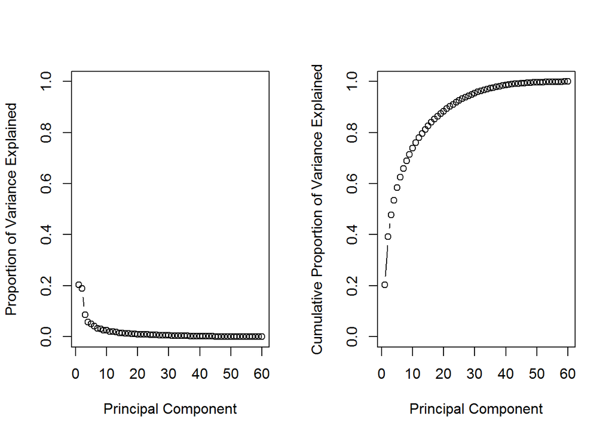

```r
## scree plots
pve<-PCA$sdev^2/sum(PCA$sdev^2)
opar<-par(no.readonly=TRUE)
par(mfrow=c(1,2))
plot(pve,xlab="Principal Component",ylab="Proportion of Variance Explained",ylim=c(0,1),
     type="b")
plot(cumsum(pve),xlab="Principal Component",
     ylab ="Cumulative Proportion of Variance Explained",ylim=c(0,1),type="b")
```

```r
par(opar)
```

Typically with scree plots, we look for an “elbow” that signals a natural selection of components (meaning that additional components beyond the “elbow” would not add significantly more information). Unfortunately, the scree plots here do not have any obvious “elbow” to aid our selection. So, we will use a couple rules of thumb:

- One rule of thumb regarding PCA is to choose components whose cumulative proportion is at least 0.8.
- Additionally, thinking ahead to potential models we will create, another rule of thumb is to have at least 10-15 examples for each predictor. Since we have 208 examples, we would ideally target between 13 and 20 predictors.

Using both of these, we will settle on 14 Principal Components as it gives us greater than 0.8 cumulative proportion of variance and produces a nicer variable to sample size ratio.

```r
set.seed(4)
## get final dimension-reduced dataset, adding the DV back on
data_from_PCA<-data.frame(PCA$x[,1:14],Type=sonar$Type)
head(data_from_PCA)
```

```
##          PC1       PC2        PC3        PC4        PC5        PC6
## 1  1.8946495  1.371755 -1.6665033  0.8516496 -1.0513681 -1.7168121
## 2 -0.5272975 -7.545821 -1.2834711  3.8860167  2.0967107  2.1818930
## 3  3.8518451 -6.441433 -0.0449075  5.4107929  1.5623875 -1.2015248
## 4  4.5760066  3.106338 -1.7895788 -1.1048838 -2.7842416  2.0435275
## 5 -0.5368722 -1.845746 -0.8531499  3.2945464  2.7947294  0.8012751
## 6 -1.2690774 -3.765797 -1.9568245  3.0600831  0.5327837  4.3298402
##          PC7        PC8        PC9       PC10       PC11        PC12
## 1  1.8140771  1.5452958  0.3770878 1.01170982  0.6130126  0.32888258
## 2 -1.7448016 -1.4693259  0.3410435 1.34697986 -0.3148478 -0.53609431
## 3 -1.7585151  1.5667406 -1.1522557 1.06558252  0.5283888  0.41397349
## 4  2.0380562 -1.7964564  0.5112307 1.04782151 -0.9285038  0.04994962
## 5  0.3354212 -0.8029094  0.1848971 0.05172525  1.3140605 -1.64652230
## 6 -2.0879250 -1.8799707  0.7692909 1.42548321  1.8423171 -1.07835879
##         PC13       PC14 Type
## 1  0.3107104  0.3921077    R
## 2  0.1699102  0.9259465    R
## 3 -1.9831065  1.2516900    R
## 4 -1.3851403 -0.2486575    R
## 5  0.7865875 -1.1319835    R
## 6  0.1740281  0.1373671    R
```

## Sidenote: PCA Aiding Visualization of K-Means Clustering

The nature of our data and task does not necessarily call for a K-Means Cluster analysis. This is because our variables are very similar (only different frequency bands recording the same type of energy), which makes segmentation analysis not super useful. However, we will use it here for the opportunity to illustrate how the PCA done above can help visualize cluster separation.

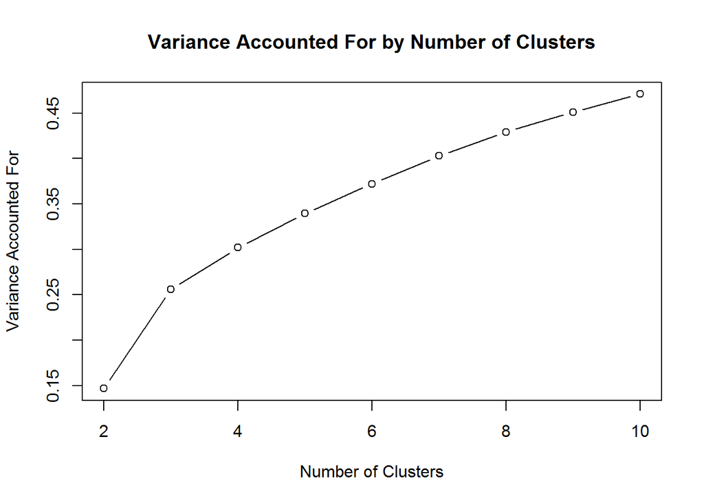

```r
set.seed(4)

## run kmeans on scaled data in iterative function form to get Variance Accounted For for various k clusters
VAFs<-function(data,nc.min=2,nc.max=25,seed=132435){
        set.seed(seed)
        vaf<-0
        for(i in nc.min:nc.max){
                k<-kmeans(data,centers=i,nstart=100)
                vaf[i]<-k$betweenss/k$totss
        }
        vaf[-1]
}

VAF<-VAFs(scaled_data,nc.max=10)

## Scree Plots
plot(2:10,VAF,type="b",xlab="Number of Clusters",ylab="Variance Accounted For")
title("Variance Accounted For by Number of Clusters")
```

Here, again, we would like to see an obvious elbow on the scree plots to help us choose an appropriate number of clusters. This scree plot doesn’t give us a great elbow. However, we get the sharpest angle at k=3, so we’ll go with that.

```r
set.seed(4)
library(knitr)

## After choosing 3 Clusters, running kmeans again
K3<-kmeans(scaled_data,centers=3,nstart=100)
## number of observations in each cluster
kable(as.data.frame(table(K3$cluster)),col.names=c("Cluster","# of Obs."),
      caption="Observations per Cluster")
```

Observations per Cluster

| Cluster | # of Obs. |
| --- | --- |
| 1 | 83 |
| 2 | 39 |
| 3 | 86 |

Now that we have our clusters, we can plot some variables against one another to visualize the separation among cluster. However, as we’ll see, high-dimensional datasets such as this one make it difficult to distinguish between clusters.

```r
set.seed(4)
library(vegan)
```

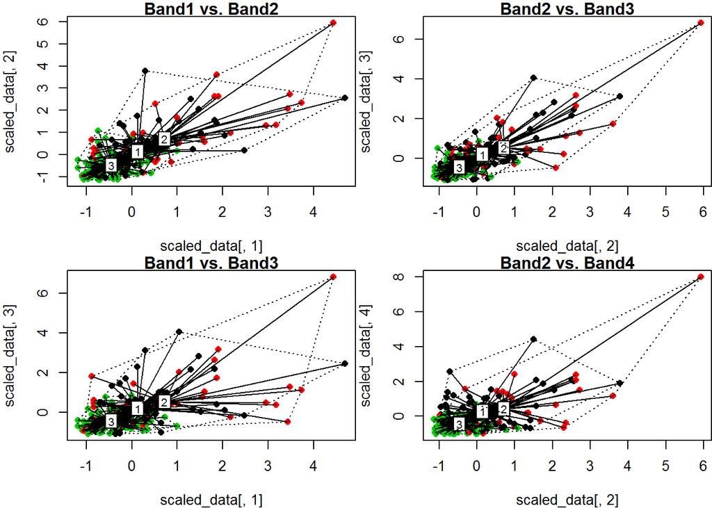

```r
## plot various IV's with color for clusters
par(mfrow=c(2,2),mar=c(4,4,1,0))
plot(scaled_data[,1], scaled_data[,2],col=K3$cluster,pch=16)
title("Band1 vs. Band2")
# plot spiderweb and connect outliners with dotted line
ord<-cbind(scaled_data[,1], scaled_data[,2])
ordispider(ord, factor(K3$cluster), label = TRUE)
ordihull(ord, factor(K3$cluster), lty = "dotted")

plot(scaled_data[,2], scaled_data[,3],col=K3$cluster,pch=16)
title("Band2 vs. Band3")
# plot spiderweb and connect outliners with dotted line
ord<-cbind(scaled_data[,2], scaled_data[,3])
ordispider(ord, factor(K3$cluster), label = TRUE)
ordihull(ord, factor(K3$cluster), lty = "dotted")

plot(scaled_data[,1], scaled_data[,3],col=K3$cluster,pch=16)
title("Band1 vs. Band3")
# plot spiderweb and connect outliners with dotted line
ord<-cbind(scaled_data[,1], scaled_data[,3])
ordispider(ord, factor(K3$cluster), label = TRUE)
ordihull(ord, factor(K3$cluster), lty = "dotted")

plot(scaled_data[,2], scaled_data[,4],col=K3$cluster,pch=16)
title("Band2 vs. Band4")
# plot spiderweb and connect outliners with dotted line
ord<-cbind(scaled_data[,2], scaled_data[,4])
ordispider(ord, factor(K3$cluster), label = TRUE)
ordihull(ord, factor(K3$cluster), lty = "dotted")
```

```r
par(opar)
```

Not very pretty. The clusters look to be all over each other. Since the data’s variation is spread out among 60 predictors, it’s near impossible to visualize the clusters on two-dimensional plots. But, utilizing the data outputted from the above PCA, we’ll get a much nicer picture. This is due to the first few components comprising the bulk of the variation.

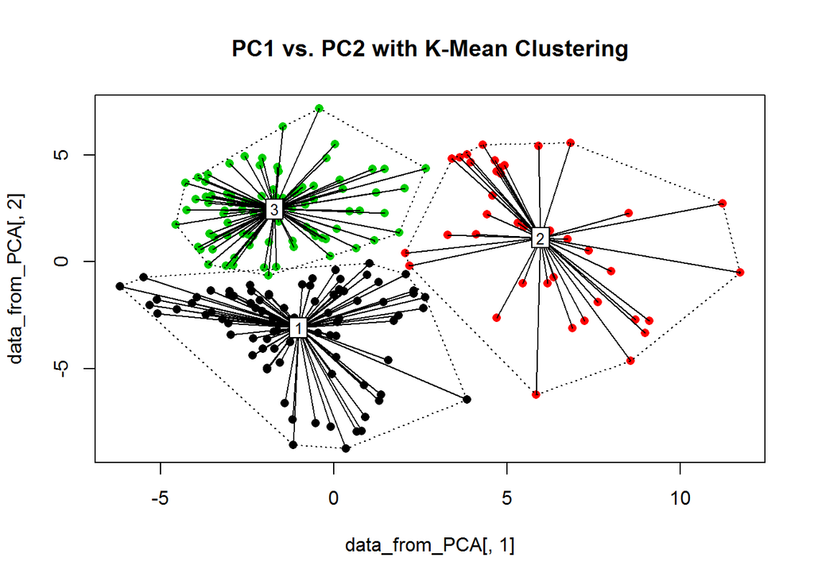

```r
set.seed(4)
# plot first 2 Principal Components w/ same Cluster Coloring
plot(data_from_PCA[,1], data_from_PCA[,2],col=K3$cluster,pch=16)
# plot spiderweb and connect outliners with dotted line
ord<-cbind(data_from_PCA[,1], data_from_PCA[,2])
ordispider(ord, factor(K3$cluster), label = TRUE)
ordihull(ord, factor(K3$cluster), lty = "dotted")
title("PC1 vs. PC2 with K-Mean Clustering")
```

A much more palatable visual solution! Now on to some supervised learning methods where we will predict Rocks vs. Mines.

## **SUPERVISED LEARNING TECHNIQUES**

Below, we explore different kinds of predictive models aimed at accurately classifying objects as rocks or mines. For each, we will use K-Fold Cross Validation to judge the accuracy of the models. A Train/Test Split Validation was also considered for this task. However, since the overall dataset is small, the results would be affected greatly by which specific test points were randomly chosen. K-Fold Cross Validation will look at multiple test sets, which will mitigate the influence of any one in particular.

For each model, there is a tuneable parameter that we will also try to optimize. To do this, we will Cross Validate the models over a wide range of these parameters. For each model, these are:

- Logistic Regression - thresh: threshold at which a predicted probability is classified as a Mine or Rock.
- Random Forest - mtry: number of variables randomly sampled at each split in each tree.
- Support Vector Machine - cost: the cost of constraint violation.

After Cross Validating a model for each tuneable parameter value, we’ll observe two different measures of accuracy: Area Under ROC Curve (to be maximized) & Misclassification Rate (to be minimized). Hopefully, the best of both of these will align with the same parameter value.

First, we’ll do some brief data prep for our cross validations. Randomizing the observations in our dataset will ensure that each fold will be as representative of the whole dataset as possible.

### Data Prep for Cross Validation

```r
set.seed(4)
library(bestglm)
library(randomForest)
library(ROSE) # for roc.curve() to get AUC
library(e1071)

#### Data Partition Prepping ####

## We can't assume our data is in a random order (in fact, it's not), so will randomize it
rand_order<-sample(1:nrow(sonar))
data<-sonar[rand_order,]

## Set number of folds we'll use
k<-8  # number of folds
## note: chose k=8 because 8 divides evenly into 208, which helps us avoid going out of bounds with the test sets
n<-floor(nrow(data)/k)  # size of each fold
```

### Logistic Regression

```r
set.seed(4)
## logistic model on raw data
log_mod_raw<-glm(Type~.,data=data,family=binomial)
```

```
## Warning: glm.fit: algorithm did not converge
```

```
## Warning: glm.fit: fitted probabilities numerically 0 or 1 occurred
```

Immediately, we see warning messages regarding the algorithm not converging and that fitted probabilities numerically 0 or 1 occurred. These are potentially due to the high number of predictors that we have. As such, this feels like a good opportunity to use our dimension-reduced dataset that was produced from the PCA above.

```r
set.seed(4)

## redoing some data prep steps on PCA data
data_from_PCA<-data_from_PCA[rand_order,]

## logistic model on PCA-dimension-reduced data
log_mod_PCA<-glm(Type~.,data=data_from_PCA,family=binomial)  # runs OK

#### Determine if any variables should be dropped to better the model
## run drop1() to determine which variables should be dropped
drop1(log_mod_PCA)
```

```
## Single term deletions
##
## Model:
## Type ~ PC1 + PC2 + PC3 + PC4 + PC5 + PC6 + PC7 + PC8 + PC9 +
##     PC10 + PC11 + PC12 + PC13 + PC14
##        Df Deviance    AIC
## <none>      154.71 184.71
## PC1     1   172.30 200.30
## PC2     1   182.48 210.48
## PC3     1   232.68 260.68
## PC4     1   154.78 182.78
## PC5     1   155.13 183.13
## PC6     1   155.29 183.29
## PC7     1   166.00 194.00
## PC8     1   154.81 182.81
## PC9     1   180.45 208.45
## PC10    1   166.73 194.73
## PC11    1   154.79 182.79
## PC12    1   154.77 182.77
## PC13    1   154.74 182.74
## PC14    1   161.82 189.82
```

```r
## run betstglm() to see if it agrees
bestglm(data_from_PCA,family=binomial)
```

```
## Morgan-Tatar search since family is non-gaussian.
```

```
## BIC
## BICq equivalent for q in (0.31246789920859, 0.904296827719038)
## Best Model:
##               Estimate Std. Error   z value     Pr(>|z|)
## (Intercept) -0.5165771 0.21312576 -2.423814 1.535849e-02
## PC1         -0.3046578 0.07603834 -4.006634 6.159015e-05
## PC2          0.3159795 0.07043747  4.485957 7.258723e-06
## PC3         -1.0035730 0.15777362 -6.360842 2.006511e-10
## PC7         -0.5132308 0.16193284 -3.169405 1.527513e-03
## PC9          0.8902113 0.20722839  4.295798 1.740661e-05
## PC10         0.6269839 0.19074117  3.287093 1.012276e-03
## PC14         0.5607720 0.21807696  2.571441 1.012763e-02
```

Both drop1() and bestglm() agree that dropping PC4, PC5, PC6, PC8, PC11, PC12, and PC13 will improve our logistic model. So, we’ll only keep the remaining seven PC variables and proceed with Cross Validation and Parameter Optimization.

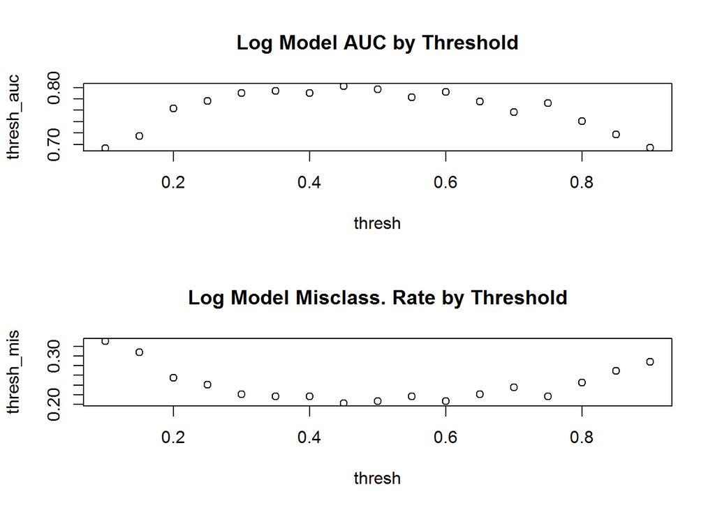

```r
set.seed(4)
########################################################
#### CV & Threshold Optimization for Logistic Model ####
########################################################

# set vectors to catch AUC and Misclassification Rates
err_vect<-rep(NA,k)
mis_vect<-rep(NA,k)

## set thresholds to test with. We'll range between 0.1 and 0.9 by 0.05
thresh<-seq(0.1,.9,.05)
thresh_auc<-c()
thresh_mis<-c()

for (j in thresh){
        for (i in 1:k){
                ## make subsets for each fold
                s1<-((i-1)*n+1)  # start of subset
                s2<-(i*n)  # end of subset
                subset<-s1:s2  # range of the subset

                cv_train<-data_from_PCA[-subset,]  # train data to make model with
                cv_test<-data_from_PCA[subset,]  # test data to test performance

                ## fit model on train set - set formula to only use significant variables
                fit<-glm(Type~PC1+PC2+PC3+PC7+PC9+PC10+PC14,data=cv_train,family=binomial)
                ## make prediction on test set
                prediction<-predict(fit,newdata=cv_test,type="response")

                ## turn probabilities into Mine/Rock output according to threshold
                predclass<-prediction
                predclass[predclass >= j]<-'R'
                predclass[predclass != 'R']<-'M'

                ## calculate model accuracy per i-th fold
                err_vect[i]<-roc.curve(cv_test[,15],predclass,plotit=FALSE)$auc
                mis_vect[i]<-mean(predclass!=cv_test[,15])
                #print(paste("AUC for fold", i, ":",err_vect[i]))
                #print(paste("Misclassification Rate for fold", i, ":",mis_vect[i]))
        }
        thresh_auc<-append(thresh_auc,mean(err_vect))  # collect mean AUC per each threshold
        thresh_mis<-append(thresh_mis,mean(mis_vect))  # collect mean Miscl. Rate per each threshold
}

## plot Threshold vs. AUC and Misclassification Rate
par(mfrow=c(2,1))
plot(thresh,thresh_auc)
title("Log Model AUC by Threshold")
plot(thresh,thresh_mis)
title("Log Model Misclass. Rate by Threshold")
```

```r
## find Thresholds for best AUC's and best M.R.
thresh_all<-data.frame(thresh,thresh_auc,thresh_mis)
head(thresh_all[order(-thresh_all$thresh_auc),],3)  ## show top 3 three best AUC
```

```
##   thresh thresh_auc thresh_mis
## 8   0.45  0.8028464  0.2019231
## 9   0.50  0.7965235  0.2067308
## 6   0.35  0.7939004  0.2163462
```

```r
head(thresh_all[order(thresh_all$thresh_mis),],3)  ## show top 3 best Misclassification Rate
```

```
##    thresh thresh_auc thresh_mis
## 8    0.45  0.8028464  0.2019231
## 9    0.50  0.7965235  0.2067308
## 11   0.60  0.7919219  0.2067308
```

Comparing the best AUC and best Misclassification Rates, thresh=0.45 gives us the best of both. So, if we choose this model in the end, we would proceed with these settings.

```r
set.seed(4)
## now fit logistic model with optimized threshold parameter
log_mod_final<-glm(Type~PC1+PC2+PC3+PC7+PC9+PC10+PC14,data=data_from_PCA,family=binomial)
threshold<-0.45
```

After Cross-Validation and Parameter Optimization, our Logistic model gives us an Area Under ROC Curve of 0.8028 and a misclassification rate of 0.2019. This doesn’t look particularly sexy, but its less-than-stellar performance may be due to using the dimension-reduced PCA output instead of the entire original dataset. Let’s see if a Random Forest model can do any better.

### Random Forest Model

A Random Forest model works much differently than the Logistic one above. Thus, we may not have a problem using the original dataset with all 60 predictors.

```r
set.seed(4)
## initial random forest model on full dataset
rf_mod<-randomForest(x=data[,-61],y=data[,61]) # runs OK
```

The Random Forest Model runs just fine on the full 60-predictor dataset, so we won’t need to use the dimension-reduced set and risk losing useful information.

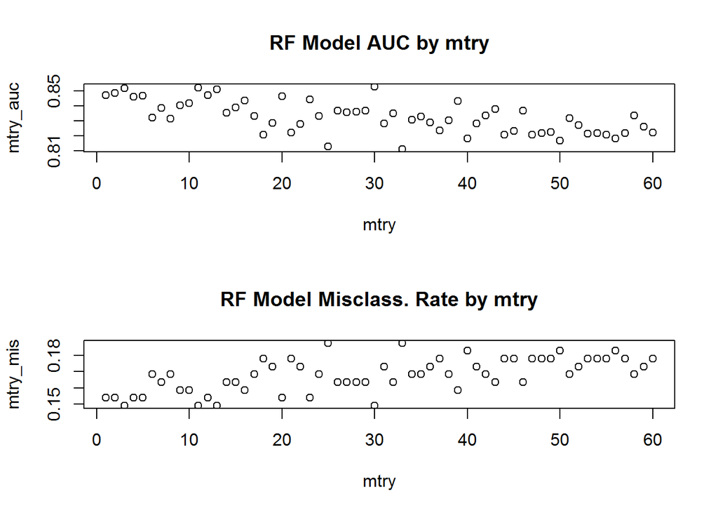

```r
set.seed(4)
########################################################
#### CV & Mtry Optimization for Random Forest Model ####
########################################################
err_vect<-rep(NA,k)
mis_vect<-rep(NA,k)

## mtry is tuneable paramter that we'll iterate through and CV each one
mtry<-seq(1,60,1) ## test mtry with every number of variables, 1 to 60
mtry_auc<-rep(NA,length(mtry))
mtry_mis<-rep(NA,length(mtry))

for (j in mtry){
        for (i in 1:k){
                ## make subsets for each fold
                s1<-((i-1)*n+1)  # start of subset
                s2<-(i*n)  # end of subset
                subset<-s1:s2  # range of the subset

                cv_train<-data[-subset,]  # train data to make model with
                cv_test<-data[subset,]  # test data to test performance

                ## fit model on train set
                fit<-randomForest(x=cv_train[,-61],y=cv_train[,61],mtry=j)
                ## make prediction on test set
                prediction<-predict(fit,newdata=cv_test[,-61],type="response")

                ## calculate model accuracy per i-th fold
                err_vect[i]<-roc.curve(cv_test[,61],prediction,plotit=FALSE)$auc
                mis_vect[i]<-mean(prediction!=cv_test[,61])
                #print(paste("AUC for fold", i, ":",err_vect[i]))
                #print(paste("Misclassification Rate for fold", i, ":",mis_vect[i]))
        }
        mtry_auc[j]<-mean(err_vect)
        mtry_mis[j]<-mean(mis_vect)
}
## plot mtry vs. AUC and Misclassification Rate
par(mfrow=c(2,1))
plot(mtry,mtry_auc)
title("RF Model AUC by mtry")
plot(mtry,mtry_mis)
title("RF Model Misclass. Rate by mtry")
```

```r
## find mtry values for best AUC's and best M.R.
mtry_all<-data.frame(mtry,mtry_auc,mtry_mis)
head(mtry_all[order(-mtry_all$mtry_auc),],3)  ## show top 3 three best AUC
```

```
##    mtry  mtry_auc  mtry_mis
## 30   30 0.8531052 0.1490385
## 11   11 0.8521208 0.1490385
## 3     3 0.8517930 0.1490385
```

```r
head(mtry_all[order(mtry_all$mtry_mis),],3)  ## show top 3 best Misclassification Rate
```

```
##    mtry  mtry_auc  mtry_mis
## 3     3 0.8517930 0.1490385
## 11   11 0.8521208 0.1490385
## 13   13 0.8513195 0.1490385
```

```r
## There are many values of mtry that give the same M.R. minimum, 0.1490. So we choose the best AUC that aligns with this.

## We have a winner. Now, we can fit our final Random Forest Model with mtry=30 on the entire dataset
rf_mod_final<-randomForest(x=data[,-61],y=data[,61],mtry=30)
```

The Random Forest model, using all 60 predictors, did quite a bit better than the Logistic Model with the PCA-given data. Setting mtry=30 gives us the best AUC and Misclassification Rate, with scores 0.8531 and 0.1490, respectively.